# Lab 01 - Hello R - Exercise

Lan Zhang

2021-September-12

### Load packages

```r
library(tidyverse)
library(datasauRus)
```

### Exercise 1

```r
dim(datasaurus_dozen)
```

```
## [1] 1846    3
```

```r
datasaurus_dozen %>%
  count(dataset) %>%
  print() #show all the variables/datasets
```

```
## # A tibble: 13 × 2
##    dataset        n
##    <chr>      <int>
##  1 away         142
##  2 bullseye     142
##  3 circle       142
##  4 dino         142
##  5 dots         142
##  6 h_lines      142
##  7 high_lines   142
##  8 slant_down   142
##  9 slant_up     142
## 10 star         142
## 11 v_lines      142
## 12 wide_lines   142
## 13 x_shape      142
```

### Exercise 2

(The answers for this Exercise are given for you below. But you should clean up some of the narrative so that it only includes what you want to turn in.)

First let’s plot the data in the dino dataset:

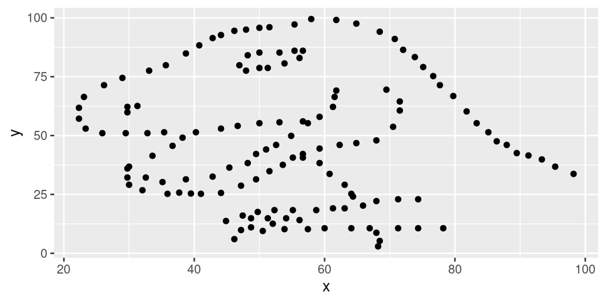

```r
dino_data <- datasaurus_dozen %>%
  filter(dataset == "dino")

ggplot(data = dino_data, mapping = aes(x = x, y = y)) +
  geom_point()
```

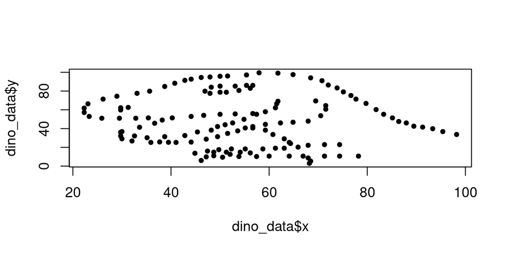

```r
# or
plot(dino_data$x, dino_data$y, pch=20)
```

And next calculate the correlation between `x` and `y` in this dataset:

```r
dino_data %>%
  summarize(r = cor(x, y))
```

```
## # A tibble: 1 × 1
##         r
##     <dbl>
## 1 -0.0645
```

```r
# or
cor(dino_data$x, dino_data$y)
```

```
## [1] -0.06447185
```

### Exercise 3

(Add code and narrative as needed. Note that the R chunks are labeled with `plot-star` and `cor-star` to provide spaces to place the code for plotting and calculating the correlation coefficient. To finish, clean up the narrative by removing these instructions.)

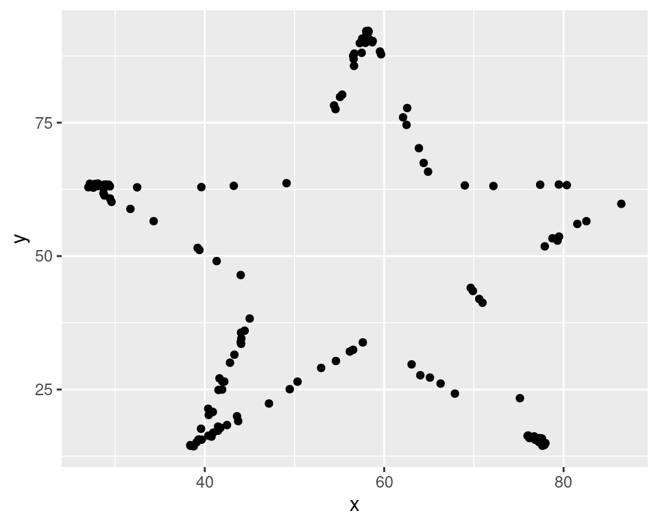

```r
star_data <- datasaurus_dozen %>%
  filter(dataset == "star")
ggplot(data = star_data, mapping = aes(x = x, y = y)) +
  geom_point()
```

```r
star_data %>%
  summarize(r = cor(x, y))
```

```
## # A tibble: 1 × 1
##         r
##     <dbl>
## 1 -0.0630
```

```r
# correlation coefficient for star dataset is larger than the one for dino data.
```